# Stress regulation via being in nature and social support in adults: a meta-analysis

Ivan Ropovik & Alessandro Sparacio

2022-10-05

**This is the supplementary analytic output for the paper Stress regulation via being in nature and social support in adults: a meta-analysis**

**It reports detailed results for all models reported in the paper. The analytic R script by which this html report was generated can be found on the project’s OSF page at: https://osf.io/6wpav/**

**Brief information about the methods used in the analysis:**

**RMA results with model-based SEs** k = number of studies; sqrt in “Variance components” = tau, the standard deviation of true effects; estimate in “Model results” = naive MA estimate

**RVE SEs with Satterthwaite small-sample correction** Estimate based on a multilevel RE model with constant sampling correlation model (CHE - correlated hierarchical effects - working model) (Pustejovsky & Tipton, 2020; https://osf.io/preprints/metaarxiv/vyfcj/). Interpretation of naive-meta-analysis should be based on these estimates.

**Prediction interval** Shows the expected range of true effects in similar studies. As an approximation, in 95% of cases the true effect in a new *published* study can be expected to fall between PI LB and PI UB. Note that these are non-adjusted estimates. An unbiased newly conducted study will more likely fall in an interval centered around bias-adjusted estimate with a wider CI width.

**Heterogeneity** Tau can be interpreted as the total amount of heterogeneity in the true effects. I^2$ represents the ratio of true heterogeneity to total variance across the observed effect estimates. Estimates calculated by two approaches are reported. This is followed by separate estimates of between- and within-cluster heterogeneity and estimated intra-class correlation of underlying true effects.

**Proportion of significant results** What proportion of effects were statistically at the alpha level of .05.

**ES-precision correlation** Kendalls’s correlation between the ES and precision.

**PET-PEESE** Estimated effect size of an infinitely precise study. Using 4/3PSM as the conditional estimator instead of PET (can be changed to PET). If the PET-PEESE estimate is in the opposite direction, the effect can be regarded nil. By default (can be changed to PET), the function employs a modified sample-size based estimator (see https://www.jepusto.com/pet-peese-performance/). It also uses the same RVE sandwich-type based estimator in a CHE (correlated hierarchical effects) working model with the identical random effects structure as the primary (naive) meta-analytic model.

We report results for both, PET and PEESE, with the first reported one being the primary (based on the conditional estimator).

**WAAP-WLS** The combined WAAP-WLS estimator (weighted average of the adequately powered - weighted least squares) tries to identify studies that are adequately powered to detect the meta-analytic effect. If there is less than two such studies, the method falls back to the WLS estimator (Stanley & Doucouliagos, 2015). If there are at least two adequately powered studies, WAAP returns a WLS estimate based on effects from only those studies.

type = 1: WAAP estimate, 2: WLS estimate. kAdequate = number of adequately powered studies

**p-uniform** P-uniform* is a selection model conceptually similar to p-curve. It makes use of the fact that p-values follow a uniform distribution at the true effect size while it includes also nonsignificant effect sizes. Permutation-based version of p-uniform method, the so-called p-uniform* (van Aert, van Assen, 2021).

**p-curve** Permutation-based p-curve method. Output should be self-explanatory. For more info see p-curve.com

**Power for detecting SESOI and bias-corrected parameter estimates** Estimates of the statistical power for detecting a smallest effect sizes of interest equal to .20, .50, and .70 in SD units (Cohen’s d). A sort of a thought experiment, we also assumed that population true values equal the bias-corrected estimates (4/3PSM or PET-PEESE) and computed power for those.

**Handling of dependencies in bias-correction methods** To handle dependencies among the effects, the 4PSM, p-curve, p-uniform are implemented using a permutation-based procedure, randomly selecting only one focal effect (i.e., excluding those which were not coded as being focal) from a single study and iterating nIterations times. Lastly, the procedure selects the result with the median value of the ES estimate (4PSM, p-uniform) or median z-score of the full p-curve (p-curve).

# Descriptives

## Publication year

### Publication year for Being in nature

```
## from   to
## 1993 2021
```

### Publication year for Social support

```
## from   to
## 1997 2021
```

## Sample sizes

### N of effects for Being in nature

```
## [1] 54
```

### N of effects for Social support

```
## [1] 18
```

### N of studies for Being in nature

```
## [1] 16
```

### N of studies for Social support

```
## [1] 13
```

### N of papers for Being in nature

```
## [1] 15
```

### N of papers for Social support

```
## [1] 13
```

### Median N across all the ES eligible for meta-analysis for Being in nature

```
## [1] 52.5
```

### Median N across all the ES eligible for meta-analysis for Social support

```
## [1] 186
```

### Total meta-analytic N for Being in nature

```
## [1] 1697
```

### Total meta-analytic N for Social support

```
## [1] 3787
```

### Mean gender ratio (percent female) for Being in nature

```
##     Mean       SD
## 49.90571 32.49089
```

### Mean gender ratio (percent female) for Social support

```
##     Mean       SD
## 45.09786 38.42652
```

### Weighted mean age of included samples for Being in nature

```
## [1] 29.54122
```

### Weighted mean age of included samples for Social support

```
## [1] 47.71785
```

# Meta-analysis results

## Being in nature

```
## $`RMA results with model-based SEs`
##
## Multivariate Meta-Analysis Model (k = 54; method: REML)
##
## Variance Components:
##
##             estim    sqrt  nlvls  fixed        factor
## sigma^2.1  0.1128  0.3358     16     no         study
## sigma^2.2  0.0853  0.2920     54     no  study/result
##
## Test for Heterogeneity:
## Q(df = 53) = 361.3608, p-val < .0001
##
## Model Results:
##
## estimate      se     zval    pval    ci.lb    ci.ub
##  -0.4211  0.1084  -3.8848  0.0001  -0.6335  -0.2086  ***
##
## ---
## Signif. codes:  0 '***' 0.001 '**' 0.01 '*' 0.05 '.' 0.1 ' ' 1
##
##
## $`RVE SEs with Satterthwaite small-sample correction`
## $`RVE SEs with Satterthwaite small-sample correction`$test
##     Coef. Estimate    SE t-stat d.f. p-val (Satt) Sig.
## 1 intrcpt   -0.421 0.109  -3.86 14.3      0.00166   **
##
## $`RVE SEs with Satterthwaite small-sample correction`$CIs
##      Coef Estimate    SE d.f. Lower 95% CI Upper 95% CI
## 1 intrcpt   -0.421 0.109 14.3       -0.654       -0.188
##
##
## $`Prediction interval`
## 95% PI LB 95% PI UB
##    -1.397     0.555
##
## $Heterogeneity
##                           Tau                           I^2
##                     0.4450121                    85.7479248
##                 Jackson's I^2 Between-cluster heterogeneity
```

[output cut: 71 more lines]

```
## - Evidential value present: yes
## - Evidential value absent/inadequate: no
##
##
## $`Power for detecting SESOI and bias-corrected parameter estimates`
## Median power for detecting a SESOI of d = .20
##                                         0.174
## Median power for detecting a SESOI of d = .50
##                                         0.718
## Median power for detecting a SESOI of d = .70
##                                         0.944
## Median power for detecting PET-PEESE estimate
##                                         0.791
##    Median power for detecting 4/3PSM estimate
##                                         0.858
```

## Social support

```
## $`RMA results with model-based SEs`
##
## Multivariate Meta-Analysis Model (k = 18; method: REML)
##
## Variance Components:
##
##             estim    sqrt  nlvls  fixed        factor
## sigma^2.1  0.0229  0.1512     13     no         study
## sigma^2.2  0.0034  0.0581     18     no  study/result
##
## Test for Heterogeneity:
## Q(df = 17) = 96.6541, p-val < .0001
##
## Model Results:
##
## estimate      se     zval    pval    ci.lb    ci.ub
##  -0.1394  0.0499  -2.7926  0.0052  -0.2372  -0.0416  **
##
## ---
## Signif. codes:  0 '***' 0.001 '**' 0.01 '*' 0.05 '.' 0.1 ' ' 1
##
##
## $`RVE SEs with Satterthwaite small-sample correction`
## $`RVE SEs with Satterthwaite small-sample correction`$test
##     Coef. Estimate     SE t-stat d.f. p-val (Satt) Sig.
## 1 intrcpt   -0.139 0.0498   -2.8 11.6       0.0166    *
##
## $`RVE SEs with Satterthwaite small-sample correction`$CIs
##      Coef Estimate     SE d.f. Lower 95% CI Upper 95% CI
## 1 intrcpt   -0.139 0.0498 11.6       -0.248      -0.0304
##
##
## $`Prediction interval`
## 95% PI LB 95% PI UB
##    -0.509     0.230
##
## $Heterogeneity
##                           Tau                           I^2
##                     0.1620018                    84.0673537
##                 Jackson's I^2 Between-cluster heterogeneity
```

[output cut: 71 more lines]

```
## - Evidential value present: yes
## - Evidential value absent/inadequate: no
##
##
## $`Power for detecting SESOI and bias-corrected parameter estimates`
## Median power for detecting a SESOI of d = .20
##                                         0.486
## Median power for detecting a SESOI of d = .50
##                                         0.998
## Median power for detecting a SESOI of d = .70
##                                         1.000
## Median power for detecting PET-PEESE estimate
##                                         0.173
##    Median power for detecting 4/3PSM estimate
##                                         0.163
```

# Plots

## Contour enhanced funnel plot

### Being in nature

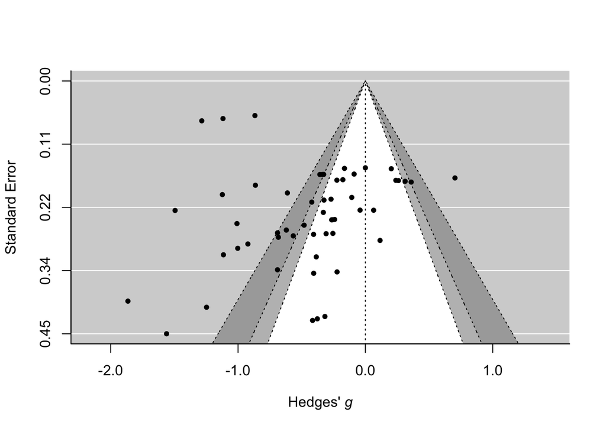

### Social support

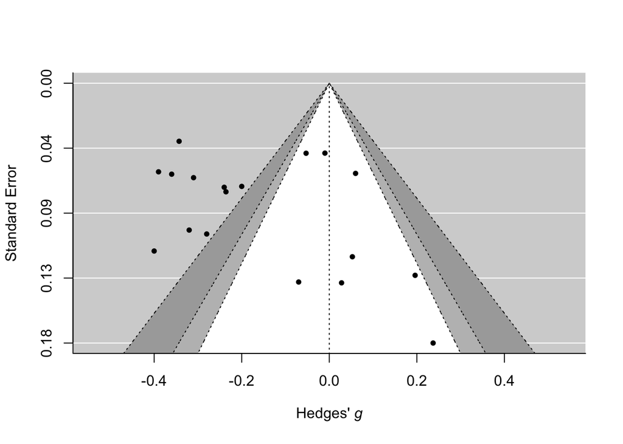

## Forest plots

### Being in nature

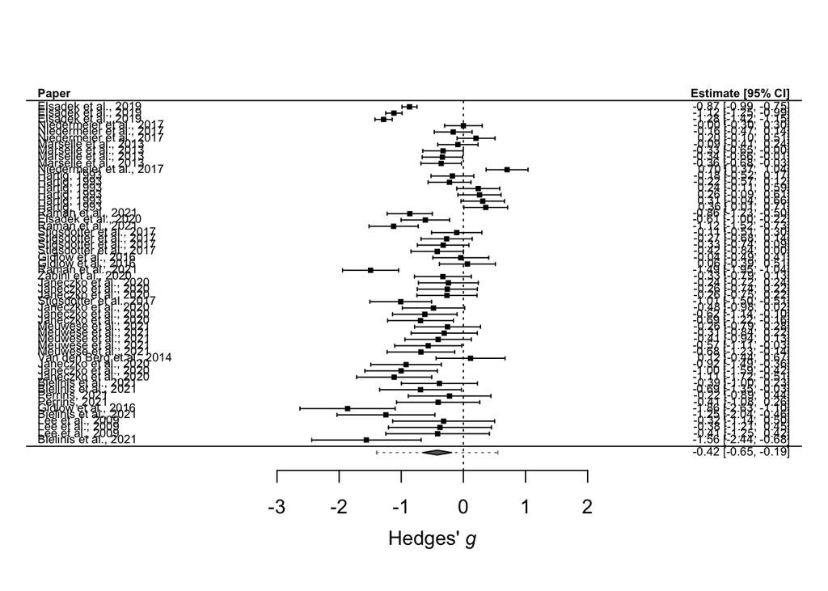

### Social support

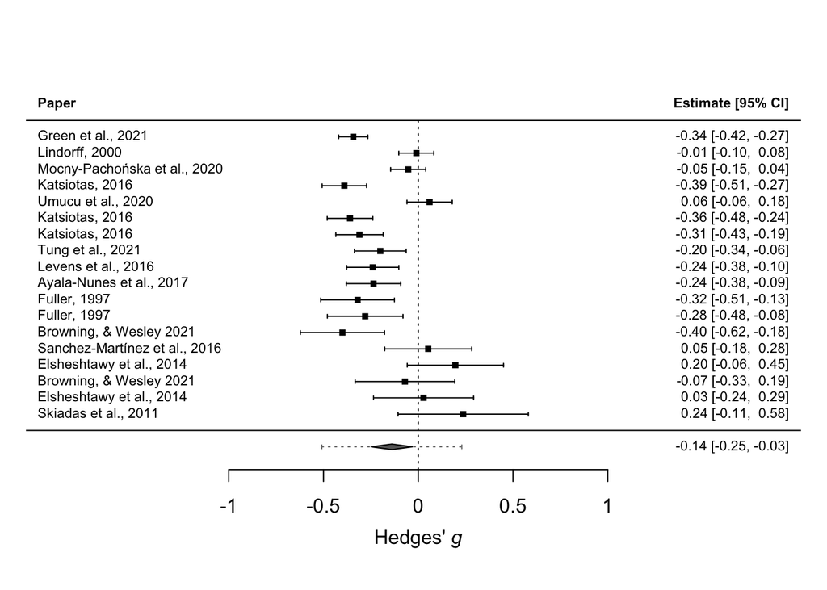

## p-curve plots

### Being in nature

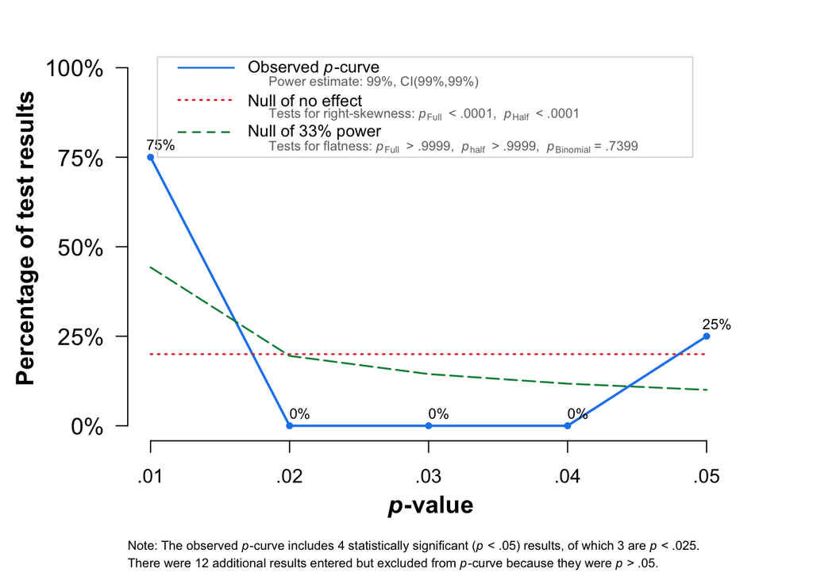

### Social support

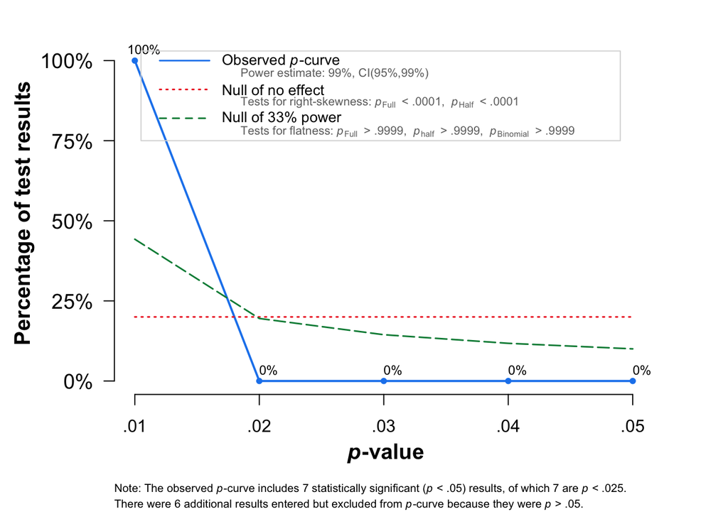

## PET-PEESE plots

Using the sqrt(2/n) and 2/n terms instead of SE and var for PET and PEESE, respectively since modified sample-size based estimator was implemented (see https://www.jepusto.com/pet-peese-performance/).

### Being in nature

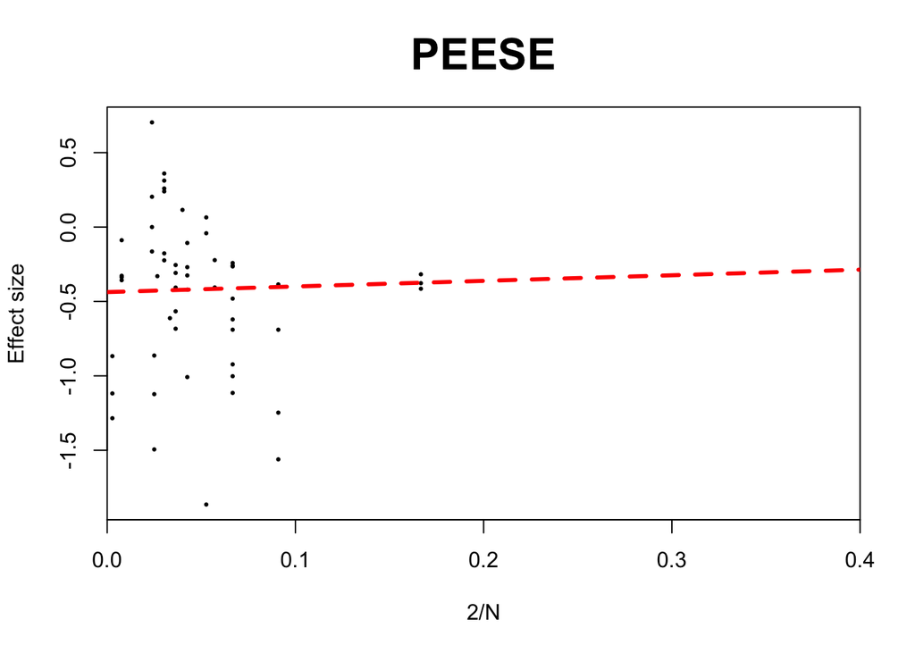

### Social support

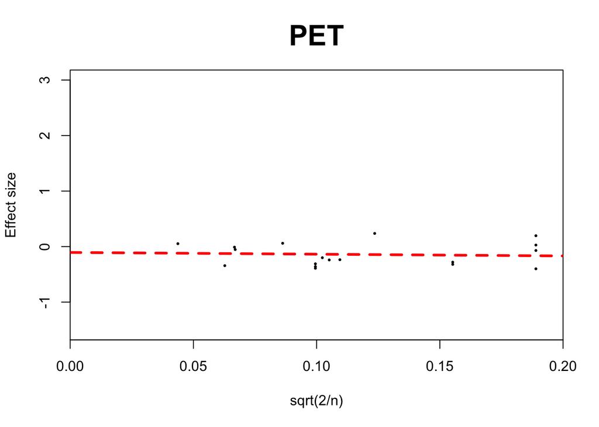

## Risk of bias assessment

### Risk of bias for Being in nature

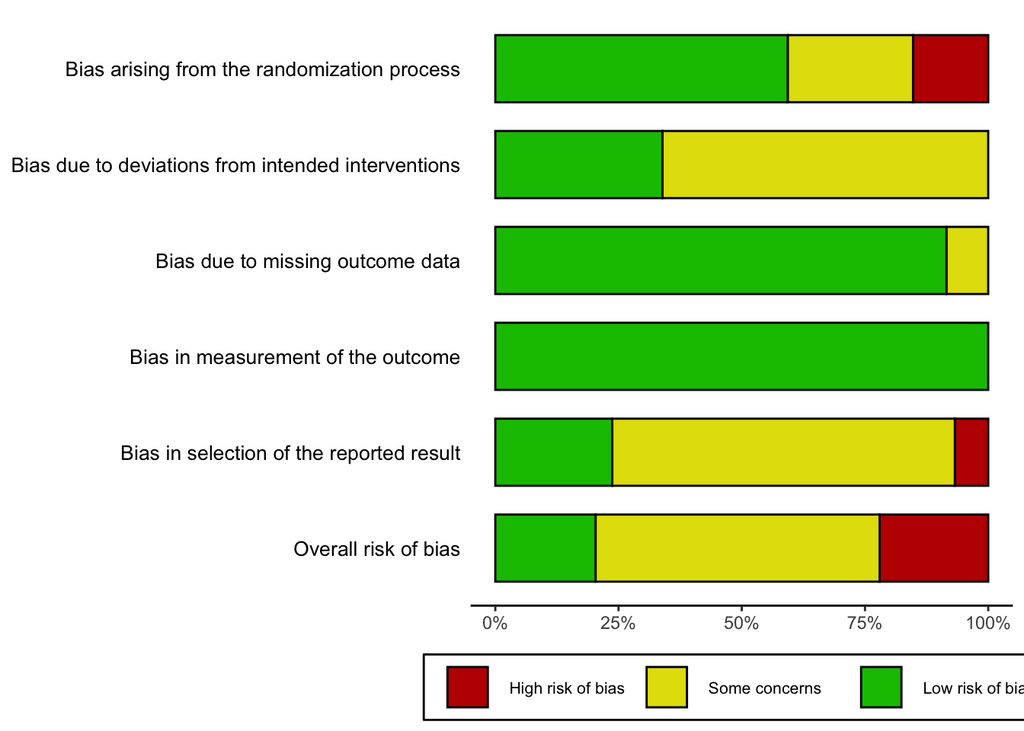

### Risk of bias for Social support

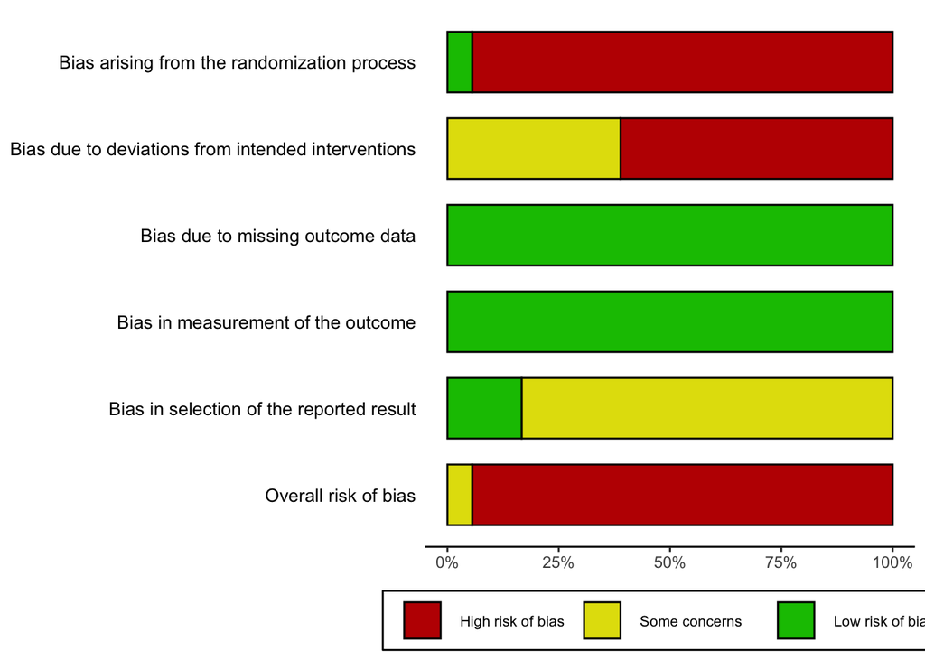

## Moderator analysis for the proportion of females

```
## $Nature
## $Nature$`Proportion of females`
## [1] 50
##
## $Nature$`Model results`
##        Coef. Estimate      SE t-stat p-val (z) Sig.
## 1 percFemale -0.00609 0.00162  -3.77    <0.001  ***
##
##
## $Social
## $Social$`Proportion of females`
## [1] 43.45
##
## $Social$`Model results`
##        Coef. Estimate      SE t-stat p-val (z) Sig.
## 1 percFemale -0.00159 0.00105   -1.5     0.133
```

## Subgroup analysis for the type of the comparison group

```
## $Nature
## $Nature[[1]]
##
##  1  2
## 10 44
##
## $Nature$`Model results`
##                          Coef. Estimate     SE t-stat p-val (z) Sig.
## 1 factor(comparisonGroupType)1    0.150 0.0251   5.98    <0.001  ***
## 2 factor(comparisonGroupType)2   -0.547 0.1011  -5.41    <0.001  ***
##
## $Nature$`RVE Wald test`
##  test Fstat df_num df_denom  p_val sig
##   HTZ  44.8      1     1.48 0.0438   *
##
##
## $Social
## $Social[[1]]
##
##  0  1
## 16  2
##
## $Social$`Model results`
##                          Coef. Estimate     SE t-stat p-val (z) Sig.
## 1 factor(comparisonGroupType)0   -0.172 0.0496  -3.46    <0.001  ***
## 2 factor(comparisonGroupType)1    0.127 0.0905   1.40      0.16
##
## $Social$`RVE Wald test`
##  test Fstat df_num df_denom p_val sig
##   HTZ  8.39      1     1.24 0.172
```

## Subgroup analysis for the population type

```
## $Nature
## $Nature[[1]]
##
##  1  2
## 29 24
##
## $Nature$`Model results`
##                     Coef. Estimate    SE t-stat p-val (z) Sig.
## 1 factor(populationType)1   -0.357 0.137  -2.61   0.00897   **
## 2 factor(populationType)2   -0.506 0.166  -3.05   0.00226   **
##
## $Nature$`RVE Wald test`
##  test Fstat df_num df_denom p_val sig
##   HTZ 0.479      1     10.6 0.504
##
##
## $Social
## $Social[[1]]
##
## 1 2 3
## 6 6 6
##
## $Social$`Model results`
##                     Coef. Estimate     SE  t-stat p-val (z) Sig.
## 1 factor(populationType)1 -0.25094 0.0712 -3.5223    <0.001  ***
## 2 factor(populationType)2 -0.13547 0.0613 -2.2091    0.0272    *
## 3 factor(populationType)3 -0.00389 0.1172 -0.0332    0.9735
##
## $Social$`RVE Wald test`
##  test Fstat df_num df_denom p_val sig
##   HTZ  1.53      2     5.96 0.292
```

## Subgroup analysis for type of exposure

```
## [[1]]
##
##  1  2  3  4
## 23  6 18  7
##
## $`Model results`
##
## Multivariate Meta-Analysis Model (k = 54; method: REML)
##
## Variance Components:
##
##             estim    sqrt  nlvls  fixed        factor
## sigma^2.1  0.1410  0.3755     16     no         study
## sigma^2.2  0.0870  0.2949     54     no  study/result
##
## Test for Residual Heterogeneity:
## QE(df = 50) = 347.4456, p-val < .0001
##
## Test of Moderators (coefficients 1:4):
## QM(df = 4) = 13.5188, p-val = 0.0090
##
## Model Results:
##
##                          estimate      se     zval    pval    ci.lb    ci.ub
## factor(typeOfExposure)1   -0.4093  0.1759  -2.3271  0.0200  -0.7540  -0.0646  *
## factor(typeOfExposure)2   -0.4339  0.3031  -1.4313  0.1523  -1.0279   0.1602
## factor(typeOfExposure)3   -0.5594  0.2610  -2.1434  0.0321  -1.0709  -0.0479  *
## factor(typeOfExposure)4   -0.3072  0.2541  -1.2087  0.2268  -0.8052   0.1909
##
## ---
## Signif. codes:  0 '***' 0.001 '**' 0.01 '*' 0.05 '.' 0.1 ' ' 1
##
##
## $`RVE Wald test`
##  test Fstat df_num df_denom p_val sig
##   HTZ 0.503      3     4.23 0.699
```

## Subgroup analysis for type of social support

```
## [[1]]
##
##  0  1  2  3
## 14  2  1  1
##
## $`Model results`
##
## Multivariate Meta-Analysis Model (k = 18; method: REML)
##
## Variance Components:
##
##             estim    sqrt  nlvls  fixed        factor
## sigma^2.1  0.0233  0.1526     13     no         study
## sigma^2.2  0.0033  0.0575     18     no  study/result
##
## Test for Residual Heterogeneity:
## QE(df = 14) = 88.1991, p-val < .0001
##
## Test of Moderators (coefficients 1:4):
## QM(df = 4) = 11.2540, p-val = 0.0239
##
## Model Results:
##
##                               estimate      se     zval    pval    ci.lb
## factor(typeOfSocialSupport)0   -0.1347  0.0561  -2.3986  0.0165  -0.2447
## factor(typeOfSocialSupport)1   -0.3006  0.1803  -1.6671  0.0955  -0.6541
## factor(typeOfSocialSupport)2    0.2371  0.2395   0.9899  0.3222  -0.2323
## factor(typeOfSocialSupport)3   -0.2360  0.1788  -1.3196  0.1870  -0.5865
##                                 ci.ub
## factor(typeOfSocialSupport)0  -0.0246  *
## factor(typeOfSocialSupport)1   0.0528  .
## factor(typeOfSocialSupport)2   0.7065
## factor(typeOfSocialSupport)3   0.1145
##
## ---
## Signif. codes:  0 '***' 0.001 '**' 0.01 '*' 0.05 '.' 0.1 ' ' 1
##
##
## $`RVE Wald test`
##  test Fstat df_num df_denom  p_val sig
##   HTZ  3751      2      1.7 <0.001 ***
```

## Subgroup analysis for source of social support

```
## [[1]]
##
##  0  1
## 17  1
##
## $`Model results`
##
## Multivariate Meta-Analysis Model (k = 18; method: REML)
##
## Variance Components:
##
##             estim    sqrt  nlvls  fixed        factor
## sigma^2.1  0.0201  0.1418     13     no         study
## sigma^2.2  0.0033  0.0575     18     no  study/result
##
## Test for Residual Heterogeneity:
## QE(df = 16) = 91.1265, p-val < .0001
##
## Test of Moderators (coefficients 1:2):
## QM(df = 2) = 11.4904, p-val = 0.0032
##
## Model Results:
##
##                         estimate      se     zval    pval    ci.lb    ci.ub
## factor(supportSource)0   -0.1573  0.0487  -3.2331  0.0012  -0.2526  -0.0619  **
## factor(supportSource)1    0.2371  0.2327   1.0187  0.3084  -0.2191   0.6932
##
## ---
## Signif. codes:  0 '***' 0.001 '**' 0.01 '*' 0.05 '.' 0.1 ' ' 1
##
##
## $`RVE Wald test`
##  test Fstat df_num df_denom  p_val sig
##   HTZ  65.7      1     10.8 <0.001 ***
```

## Excluding effects based on inconsistent means or SDs

Only for Being in nature, since there were 0 inconsistent means or SDs for Social support studies.

```
## $Nature
## $Nature$`Count of GRIM/GRIMMER inconsistencies`
##
## FALSE  TRUE
##    15    10
##
## $Nature$`Model results`
##                                                   Coef Estimate    SE d.f.
## 1 factor(as.logical(inconsistenciesCountGRIMMER))FALSE   -0.557 0.157  Inf
## 2  factor(as.logical(inconsistenciesCountGRIMMER))TRUE   -0.715 0.168  Inf
##   Lower 95% CI Upper 95% CI
## 1       -0.865       -0.249
## 2       -1.044       -0.387
##
## $Nature$`RVE Wald test`
##  test Fstat df_num df_denom p_val sig
##   HTZ  0.94      1     2.18 0.427
```

## Excluding effects due to a high risk of bias

```
## $Nature
## $Nature$RoB
##
## FALSE  TRUE
##    42    12
##
## $Nature$`Model results`
##                                             Coef Estimate    SE d.f.
## 1 factor(robOverall > acceptableRiskOfBias)FALSE   -0.367 0.120  Inf
## 2  factor(robOverall > acceptableRiskOfBias)TRUE   -0.597 0.261  Inf
##   Lower 95% CI Upper 95% CI
## 1       -0.602      -0.1322
## 2       -1.110      -0.0846
##
## $Nature$`RVE Wald test`
##  test Fstat df_num df_denom p_val sig
##   HTZ 0.638      1     3.34 0.477
##
##
## $Social
## $Social$RoB
##
## FALSE  TRUE
##     1    17
##
## $Social$`Model results`
##                                             Coef Estimate     SE d.f.
## 1 factor(robOverall > acceptableRiskOfBias)FALSE    0.237 0.0000  Inf
## 2  factor(robOverall > acceptableRiskOfBias)TRUE   -0.157 0.0486  Inf
##   Lower 95% CI Upper 95% CI
## 1        0.237        0.237
## 2       -0.253       -0.062
##
## $Social$`RVE Wald test`
##  test Fstat df_num df_denom  p_val sig
##   HTZ  65.7      1     10.8 <0.001 ***
```

## Comparison of strategies

### Model without covariates

```
## $`Model results`
##                Coef Estimate    SE d.f. Lower 95% CI Upper 95% CI
## 1 factor(strategy)1   -0.701 0.203  Inf       -1.099      -0.3032
## 2 factor(strategy)2   -0.158 0.102  Inf       -0.358       0.0406
##
## $`RVE Wald test`
##  test Fstat df_num df_denom  p_val sig
##   HTZ  5.39      1     10.5 0.0415   *
```

### Model with covariates

Controlling for design-related factors that are prognostic w.r.t. the effect sizes (i.e., might vary across moderator categories)

```
## $`Model results`
##                  Coef Estimate    SE d.f. Lower 95% CI Upper 95% CI
## 1   factor(strategy)1 -0.73444 1.944  Inf       -4.545        3.076
## 2   factor(strategy)2 -1.16232 2.025  Inf       -5.131        2.806
## 3      researchDesign  0.12006 0.317  Inf       -0.500        0.741
## 4      populationType  0.00769 0.246  Inf       -0.474        0.489
## 5 comparisonGroupType -0.37602 0.440  Inf       -1.238        0.486
## 6           published -0.08972 0.349  Inf       -0.773        0.594
## 7          robOverall  0.23530 0.317  Inf       -0.386        0.856
##
## $`RVE Wald test`
##  test Fstat df_num df_denom p_val sig
##   HTZ 0.263      1     5.15 0.629
```

### Numerical inconsistencies in reported p-values

#### Being in nature

How many results were analyzed

```
## [1] 112
```

How many papers reported results in APA format

```
## [1] 8
```

How many statcheck errors

```
##
##      FALSE       TRUE
## 0.96428571 0.03571429
```

What proportion of statcheck errors affected the decision

```
## TRUE
##  0.5
```

How many papers contained statcheck errors

```
## [1] 0.5
```

#### Social support

How many results were analyzed

```
## [1] 20
```

How many papers reported results in APA format

```
## [1] 3
```

How many statcheck errors

```
##
## FALSE  TRUE
##  0.85  0.15
```

What proportion of statcheck errors affected the decision

```
##      TRUE
## 0.6666667
```

How many papers contained statcheck errors

```
## [1] 0.6666667
```

# Moderator/sensitivity analyses

The below reported meta-regressions are all implemented as a multivariate RVE-based models using the CHE working model (Pustejovsky & Tipton, 2020; https://osf.io/preprints/metaarxiv/vyfcj/). Testing of contrasts is carried out using a robust Wald-type test testing the equality of estimates across levels of the moderator.

## Published status

```
## $Nature
## $Nature[[1]]
##
##  0  1
##  8 46
##
## $Nature$`Model results`
##                 Coef Estimate    SE d.f. Lower 95% CI Upper 95% CI
## 1 factor(published)0  -0.0333 0.212  Inf       -0.449        0.383
## 2 factor(published)1  -0.4796 0.114  Inf       -0.702       -0.257
##
## $Nature$`RVE Wald test`
##  test Fstat df_num df_denom p_val sig
##   HTZ  3.44      1     1.32 0.266
##
##
## $Social
## $Social[[1]]
##
##  0  1
##  7 11
##
## $Social$`Model results`
##                 Coef Estimate     SE d.f. Lower 95% CI Upper 95% CI
## 1 factor(published)0  -0.3150 0.0268  Inf       -0.367      -0.2625
## 2 factor(published)1  -0.0887 0.0547  Inf       -0.196       0.0185
##
## $Social$`RVE Wald test`
##  test Fstat df_num df_denom  p_val sig
##   HTZ  13.8      1     3.33 0.0284   *
```

## Excluding effects from non-randomized designs

```
## $Nature
## $Nature[[1]]
##
##  1  2  3
##  9  4 41
##
## $Nature$`Model results`
##                               Coef Estimate     SE d.f. Lower 95% CI
## 1 factor(researchDesign == 1)FALSE    -0.46 0.1435  Inf       -0.741
## 2  factor(researchDesign == 1)TRUE    -0.31 0.0984  Inf       -0.503
##   Upper 95% CI
## 1       -0.178
## 2       -0.117
##
## $Nature$`RVE Wald test`
##  test Fstat df_num df_denom p_val sig
##   HTZ  0.74      1     6.76 0.419
##
##
## $Social
## $Social[[1]]
##
##  1  3  4
##  1  1 16
##
## $Social$`Model results`
##                               Coef Estimate     SE d.f. Lower 95% CI
## 1 factor(researchDesign == 1)FALSE   -0.157 0.0486  Inf       -0.253
## 2  factor(researchDesign == 1)TRUE    0.237 0.0000  Inf        0.237
##   Upper 95% CI
## 1       -0.062
## 2        0.237
##
## $Social$`RVE Wald test`
##  test Fstat df_num df_denom  p_val sig
##   HTZ  65.7      1     10.8 <0.001 ***
```

## Subgroup analysis for stress vs affective consequences

```
## $Nature
## $Nature$`Number of included effects per category`
##
##  1  2
## 48  6
##
## $Nature$`Model results`
##                          Coef Estimate    SE d.f. Lower 95% CI Upper 95% CI
## 1 as.factor(stressAffective)1   -0.421 0.109  Inf       -0.634      -0.2078
## 2 as.factor(stressAffective)2   -0.429 0.169  Inf       -0.760      -0.0969
##
## $Nature$`RVE Wald test`
##  test   Fstat df_num df_denom p_val sig
##   HTZ 0.00305      1     5.05 0.958
##
##
## $Social
## $Social$`Number of included effects per category`
##
##  1  2
## 14  4
##
## $Social$`Model results`
##                          Coef Estimate     SE d.f. Lower 95% CI Upper 95% CI
## 1 as.factor(stressAffective)1   -0.109 0.0531  Inf       -0.214     -0.00534
## 2 as.factor(stressAffective)2   -0.262 0.0712  Inf       -0.402     -0.12254
##
## $Social$`RVE Wald test`
##  test Fstat df_num df_denom p_val sig
##   HTZ   4.3      1     2.65 0.142
```

```
## $Nature
## $Nature$`Number of included effects per category`
##
##  1  3
## 28 20
##
## $Nature$`Model results`
##                            Coef Estimate    SE d.f. Lower 95% CI Upper 95% CI
## 1 as.factor(stressCompRecoded)1   -0.488 0.156  Inf       -0.794      -0.1821
## 2 as.factor(stressCompRecoded)3   -0.306 0.149  Inf       -0.599      -0.0138
##
## $Nature$`RVE Wald test`
##  test Fstat df_num df_denom p_val sig
##   HTZ 0.609      1     5.43 0.468
##
##
## $Social
## $Social$`Number of included effects per category`
##
##  1  3
## 13  1
##
## $Social$`Model results`
##                            Coef Estimate     SE d.f. Lower 95% CI Upper 95% CI
## 1 as.factor(stressCompRecoded)1  -0.1184 0.0575  Inf      -0.2311     -0.00567
## 2 as.factor(stressCompRecoded)3   0.0527 0.0000  Inf       0.0527      0.05270
##
## $Social$`RVE Wald test`
##  test Fstat df_num df_denom  p_val sig
##   HTZ  8.85      1     9.63 0.0145   *
```

### Forest plots

#### Being in nature

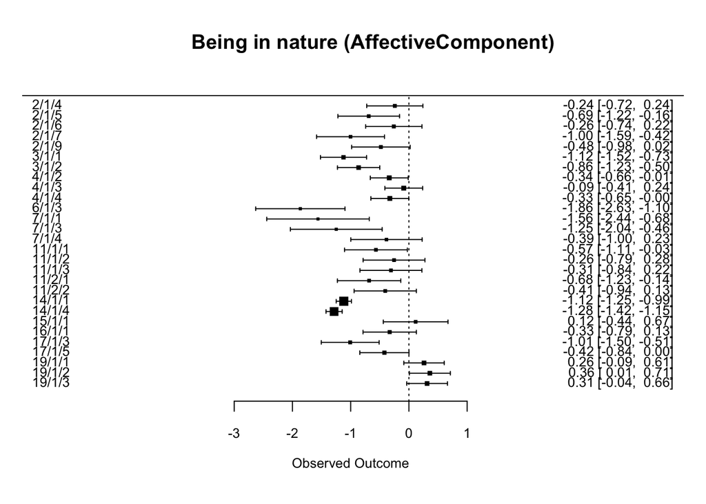

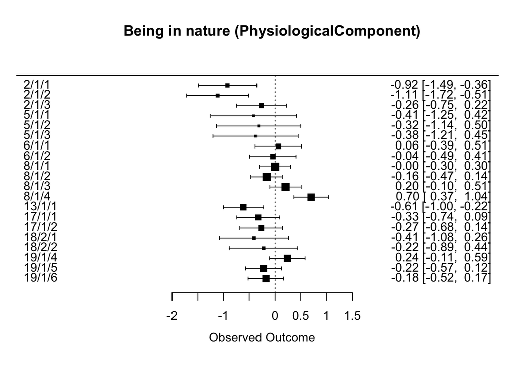

#### Social support

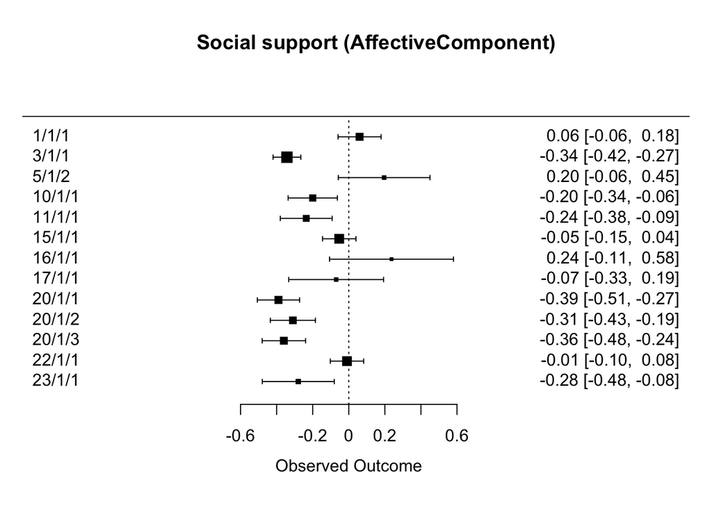

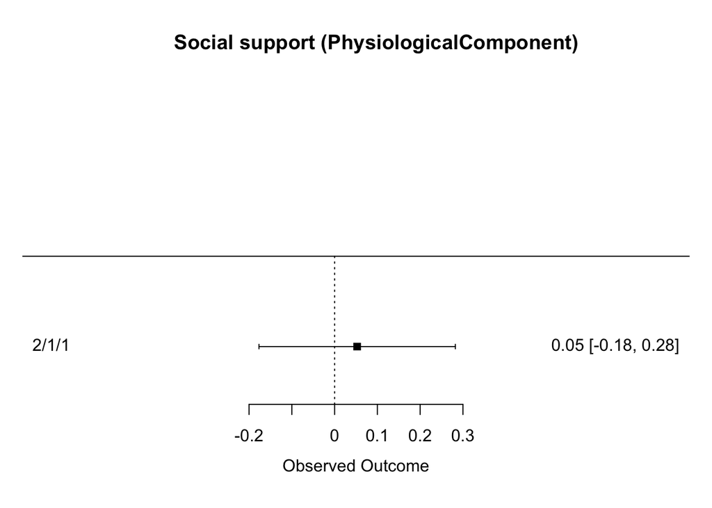